# Struktur Data

Struktur data merupakan cara programmer untuk merepresentasikan suatu data, dan memudahkan programmer untuk menyelesaikan permasalahan dengan menggunakan struktur data tersebut.

Struktur data Linear Structure merupakan struktur data sederhana dimana ketika data ditambahkan maka data tersebut berada pada posisi relatif terhadap data yang lain dari struktur data tersebut. Linear structure ini memiliki dua buah ujung. Dua buah ujung ini memiliki beberapa istilah seperti left-right, front-rear, ataupun top-bottom. Terdapat beberapa struktur data yang termasuk pada linear structure ini, yaitu :

- Stacks
- Queues
- Lists

Ketiga jenis struktur data tersebut berbeda dalam penambahan atau penghapusan suatu data. Misalkan, suatu struktur data hanya diperbolehkan menghapus data pada salah satu ujung, sedangkan pada struktur data lain, penghapusan data dapat dilakukan pada kedua ujung. Struktur data yang akan dibahas pertama kali adalah Stacks, yang terdiri dari :

1. Stacks
2. Operasi Stacks
3. Contoh Implementasi Stacks
4. Ekspressi Aritmatik Infix, Prefix, Postfix

# Definisi Stacks

Stacks adalah satu struktur data dimana penambahan dan penghapusan data, hanya dapat dilakukan pada satu ujung yang sama, atau yang biasa dikenal dengan istilah top.

Semakin data jauh berada dari posisi top, maka data tersebut diindikasikan berada di stack lebih lama dibandingkan dengan data yang berada dekat pada data di posisi top.

Jika terdapat data baru yang ditambahkan di stack, maka data ini pulalah yang akan dihapus ketika terdapat proses penghapusan data. Konsep ini dikenal dengan nama LIFO-Last In First Out.

Konsep stack ini dapat ditemui pada permasalahan sehari-hari, misalkan tumpukan buku pada Gambar 1 berikut.

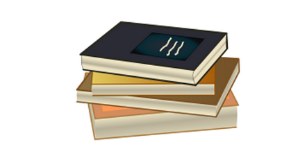

Jika kita ingin mengambil buku pada tumpukan buku tersebut, maka buku yang dapat kita ambil adalah buku yang berada di posisi teratas. Jika ingin mengambil buku yang berada di posisi paling bawah, maka kita harus mengambil buku-buku yang berada di posisi atasnya terlebih dahulu. Begitu juga ketika terdapat penambahan buku baru, maka buku baru ini akan berada di posisi paling atas.

# Operasi pada Stacks

Terdapat operasi dasar pada Stacks,

- stack (), inisialisasi stack yang kosong
- push(data), penambahan data baru pada posisi top dari stack
- pop(), penghapusan data yang terdapat di posisi top dari stack. R eturn value dari fungsi ini adalah data yang dihapus dari stack tersebut
- peek(), informasi data yang terletak pada posisi top
- isEmpty(), untuk memeriksa apakah stack dalam keadaan kosong
- size(), informasi jumlah data yang terdapat pada stack

Ilustrasi proses penambahan data atau yang dikenal dengan istilah push dapat dilihat pada Gambar 2 berikut.

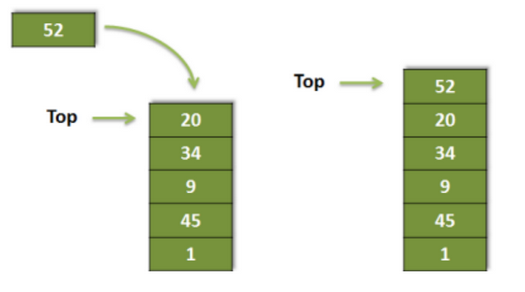

**Gambar 2. Operasi push pada Stacks**

Sedangkan proses penghapusan data atau yang dikenal dengan istilah pop dapat dilihat pada Gambar 3 berikut.

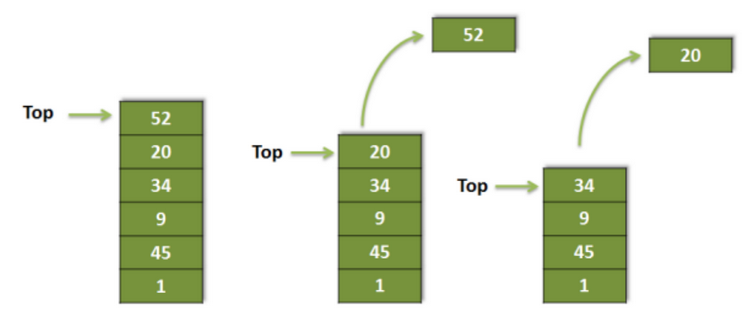

**Gambar 3. Operasi pop pada Stacks**

## Code

Berikut adalah fungsi-fungsi yang dibutuhkan untuk mengimplementasikan stacks.

```python
def stack():
    s=[]
    return (s)
def push(s,data):
    s.append(data)
def pop(s):
    data=s.pop()
    return(data)
def peek(s):
    return(s[len(s)-1])
def isEmpty(s):
    return (s==[])
def size(s):
    return(len(s))
```

Berikut adalah contoh penggunaan fungsi-fungsi stacks yang telah dibuat

```python
import Stack as st

data=st.stack()
st.isEmpty(data)

st.push(data,100)
st.push(data,23)
st.push(data,34)
st.pop(data)
st.push(data,56)
st.pop(data)
print(data)
```

[output not shown]

### Konversi Bilangan

Pada dunia ilmu komputer seringkali dibutuhkan proses konversi dari suatu bilangan ke bilangan lain, misalkan dari bilangan desimal menjadi bilangan biner atau menjadi bilangan octal. Ilustrasi proses konversi dari bilangan desimal ke bilangan biner dapat dilihat pada Gambar 4 berikut.

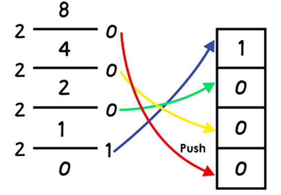

**Gambar 4. Konversi bilangan desimal ke biner**  
Dari Gambar tersebut dapat dilihat bahwa bilangan biner didapatkan dari sisa pembagian bilangan desimal dengan dua. Hasil konversi didapatkan dengan cara membaca terbalik semua sisa tersebut.

```python
#Manual Tanpa Function atau Class
stackkk=[]

stackkk.append('A')
stackkk.append('L')
stackkk.append('D')
stackkk.append('O')
print(stackkk)

elemen_akhir = stackkk[-1]

hapus_elemen = stackkk.pop()
print(stackkk)
```

```
['A', 'L', 'D', 'O']
['A', 'L', 'D']
```

```python
#Stack dengan menggunakan def/Function
def stack():
    s=[]
    return (s)
def push(s,data):
    s.append(data)
def pop(s):
    data=s.pop()
    return(data)
def peek(s):
    return(s[len(s)-1])
def isEmpty(s):
    return (s==[])
def size(s):
    return(len(s))

s=[]

push(s,100)
pop(s)
push(s,200)
pop(s)
push(s,'A')
push(s,'L')
push(s,'D')
push(s,'O')
peek(s)
```

```
'O'
```

```python
kata = 'KATAK'
A = []
B = []

def pushh(s, objek):
    for i in range(len(objek)):
        s.append(objek[i])
    print(s)

def pushh2(s, objek):
    for j in range(len(objek),0,-1):
        s.append(objek[j-1])
    print(s)

def cekKata(a,b):
    return a==b

pushh(A, kata)
pushh2(B, kata)
print(cekKata(A,B))
```

```
['K', 'A', 'T', 'A', 'K']
['K', 'A', 'T', 'A', 'K']
True
```

### Latihan - 1

Buat function untuk 'reverse word' dengan menggunakan konsep stacks, misalkan kata 'stacks' menjadi 'skcats'

```python
def reverseWord(word):
    dataStack=stack()
    for ch in word:
        push(dataStack,ch)
    temp=''
    while not(isEmpty(dataStack)):
        temp=temp+pop(dataStack)
    return temp

reverseWord('aku')
```

```
'uka'
```

### Implementasi Stacks

Berikut adalah contoh implementasi untuk penggunaan stacks, yaitu delimiter matching dan konversi desimal ke biner

### Delimiter Matching

Parentheses sering digunakan untuk urutan penyelesaian dalam persamaan Matematika, seperti contoh berikut:  
P = 5 x (4 + 5) / ((3 + 2) x (10 - 8))  
Dengan penggunaan parentheses maka persamaan tersebut dapat diselesaikan secara benar, hanya saja terkadang parentheses yang ditulis tidak lengkap, sehingga hasil persamaan tidak dapat dikerjakan atau tidak sesuai dengan yang diinginkan, seperti contoh berikut :  
P = 5 x (4 + 5) / ((3 + 2) x (10 - 8)  
Oleh karena itu diperlukan algoritma untuk pemeriksaan parentheses ini atau secara umum delimiter, yaitu '{ }', '[ ]', dan '( )'.  
Beberapa tahapan atau algoritma untuk pengecekan parentheses ini adalah :

```python
def checkParentheses(strMat):
    data= stack()
    for ch in strMat:
        if ch=='(':
            push(data,ch)
        elif ch==')':
            if stack.isEmpty(data):
                return 'kelebihan kurung tutup'
            else:
                stack.pop(data)
        if isEmpty(data):
            return True
        else:
            return 'Kelebihan kurung buka'
```

```python
checkParentheses('5 x (4 + 5) / (3 + 2) x (10 - 8))')
```

```
True
```

```python
a='5 x (4 + 5) / (3 + 2) x (10 - 8))'
'300' in a
```

```
False
```

```python
# binary
def convertBinary(num):
    temp=stack()
    divNum=num
    while divNum>0:
        push(temp,divNum%2)
        divNum=divNum//2
    tempStr=''
    for i in range(size(temp)):
        tempStr=tempStr+str(pop(temp))
    return tempStr

print(convertBinary(25))
```

```
11001
```

```python
stack = []
while True:
    teks = input('Masukkan Kata = ')

    if teks.upper() == 'UNDO':
        if stack:
            stack.pop()
            print('Berhasil melakukan UNDO')
        else:
            print('tidak kata yang di UNDO')
            break
    else:
        stack.append(teks)

    if stack:
        print('output = ',stack [-1])
    else:
        print('output kosong')
```

```
output =  aldo
output =  iqbal
Berhasil melakukan UNDO
output =  aldo
Berhasil melakukan UNDO
output kosong
tidak kata yang di UNDO
```

```python
kalimat = input("Masukkan kalimat: ")
kata = kalimat.split()          # Memisahkan kata
kata_terbalik = kata[::-1]      # Membalik urutan kata
hasil = " ".join(kata_terbalik) # Menggabungkan kembali

print('Input = ',kalimat)
print('Output = ',hasil)
```

```
Input =  minum air dan makan nasi
Output =  nasi makan dan air minum
```

```python
stack = []
panjang_data= 0

stack.append(10)
stack.append(50)
stack.append(30)
stack.append(90)
stack.append(30)

for i in stack:
    panjang_data+=1
print('jumlah elemen dalam stack = ',panjang_data)
```

```
jumlah elemen dalam stack =  5
```

```python
stack = []

stack.append(10)
stack.append(20)
stack.append(30)
stack.append(40)
stack.append(50)

print(stack)

stack.pop()
stack.pop()
stack.pop()
stack.append(40)
stack.append(50)

print(stack)
```

```
[10, 20, 30, 40, 50]
[10, 20, 40, 50]
```

```python
kata = input('masukkan kata = ')
stack = []
revers = []

def push(s, objek):
    for i in range(len(objek)):
        s.append(objek[i])
    print(s)

def push2(s, objek):
    for j in range(len(objek),0,-1):
        s.append(objek[j-1])
    print(s)

push(stack,kata)
push2(revers,kata)
```

```
['k', 'a', 's', 'u', 'r', ' ', 'r', 'u', 's', 'a', 'k']
['k', 'a', 's', 'u', 'r', ' ', 'r', 'u', 's', 'a', 'k']
```

# QUEUE

## Definisi Queues

Queues atau antrian merupakan struktur data dimana penambahan data baru dan penghapusan data berada di ujung yang berbeda. Hal ini berbeda dengan stacks, dimana penambahan data baru dan penghapusan data, dilakukan pada ujung yang sama. Pada Queues, seperti halnya antrian, penambahan data baru dilakukan di suatu ujung atau yang dikenal dengan nama rear, dan penghapusan data dilakukan pada ujung yang dikenal dengan nama front, seperti yang terlihat pada Gambar 1 berikut :

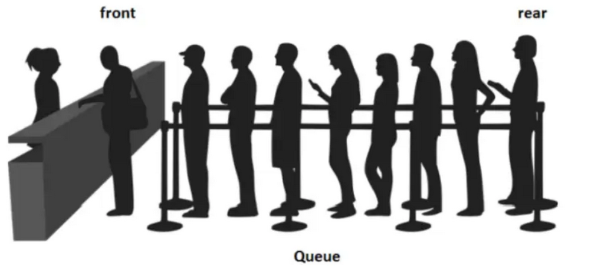

Suatu kumpulan barang yang diurutkan di mana penambahan barang baru terjadi di salah satu ujung, yang disebut "belakang," dan penghapusan barang yang sudah ada terjadi di ujung lainnya, yang umumnya disebut "depan." Prinsip pengurutan ini terkadang disebut FIFO, first-in first-out (masuk pertama keluar pertama). Ini juga dikenal sebagai "first-come first-served" (datang pertama dilayani pertama).  
Queue() membuat antrean baru yang kosong. Fungsi ini tidak memerlukan parameter dan mengembalikan antrean kosong.  
enqueue(item) menambahkan item baru ke bagian belakang antrean. Fungsi ini membutuhkan item tersebut dan tidak mengembalikan apa pun.  
dequeue() menghapus item terdepan dari antrean. Fungsi ini tidak memerlukan parameter dan mengembalikan item tersebut. Antrean dimodifikasi.  
isEmpty() memeriksa apakah antrean kosong. Fungsi ini tidak memerlukan parameter dan mengembalikan nilai boolean.  
size() mengembalikan jumlah item dalam antrean. Fungsi ini tidak memerlukan parameter dan mengembalikan bilangan bulat.

## Operasi pada Queues

Terdapat beberapa operasi dasar pada struktur data Queues ini, antara lain :

- queue (), inisialisasi struktur data queue kosong
- enqueue (data), penambahan *data* baru pada queue
- dequeue (), penghapusan data
- isEmpty(), pengecekan apakah queue dalam keadaan kosong
- size (), informasi jumlah data yang terdapat pada queue  
  Ilustrasi penambahan dan penghapusan data dapat dilihat pada Gambar 2 dan Gambar 3 berikut :

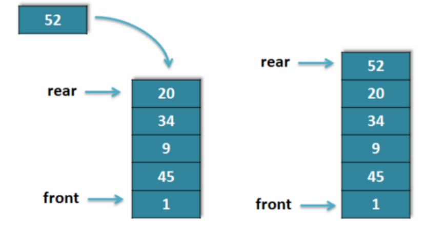

[figure not shown]

### Code

Berikut adalah code-code untuk pembentukan queues dan operasi-operasi yang terdapat pada queues

```python
def createQueue():
    q=[]
    return (q)
def enqueue(q,data):
    q.insert(0,data)
    return(q)
def dequeue(q):
    data=q.pop()
    return(data)
def isEmpty(q):
    return (q==[])
def size(q):
    return (len(q))
```

```python
q=createQueue()

enqueue(q,'matematika')
enqueue(q,'struktur data')
enqueue(q,'bahasa inggris')
enqueue(q,'pemrograman web')
print(q)
```

```
['pemrograman web', 'bahasa inggris', 'struktur data', 'matematika']
```

```python
temp=dequeue(q)
print(q)
print(temp)
```

```
['pemrograman web', 'bahasa inggris', 'struktur data']
matematika
```

```python
enqueue(q,dequeue(q))
print(q)
```

```
['struktur data', 'pemrograman web', 'bahasa inggris']
```

```python
a=dequeue(q)
print(a,q)
```

```
bahasa inggris ['struktur data', 'pemrograman web']
```

```python
enqueue(q,'new')
```

```
['new', 'struktur data', 'pemrograman web']
```

```python
isEmpty(q)
```

```
False
```

```python
size(q)
```

```
3
```

## Implementasi-Queues

Contoh implementasi queues ini adalah permainan anak-anak, yaitu permainan ular naga. Pada permainan ini, sekelompok anak berbaris dan dan terdapat dua buah anak sebagai penjaga, yang bertugas untuk 'menangkap anak' seiring dengan lagu 'ular naga' berakhir. Permainan ini akan berakhir jika hanya terdapat satu anak yang memenangkan permainan, yaitu anak tersebut lolos dari tangkapan penjaga, seperti yang terlihat pada Gambar 4

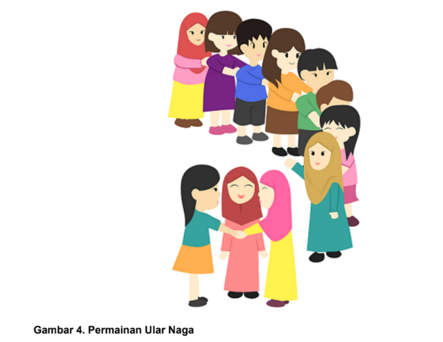

Berikut code simulasi dari permainan tersebut, dengan sedikit modifikasi, yaitu fungsi penjaga dan lagu 'ular naga' digantikan dengan bilangan tertentu, dan sekolompok anak disusun dalam suatu antrian. Permainan akan terus berjalan, sampai dengan hitungan bilangan tertentu tersebut. Jika pada hitungan tertentu, terdapat anak yang berada di ujung antrian (front), maka anak tersebut harus keluar barisan antrian. Permainan dimenangkan oleh seorang anak yang tersisa di dalam antrian.

```python
def ularNaga(nama, hitungan):
    gameQueue = createQueue()
    for namaAnak in nama:
        enqueue(gameQueue,namaAnak)
    print('Peserta Permainan=',gameQueue)
    while size(gameQueue) > 1:
        for i in range(hitungan):
            enqueue(gameQueue,dequeue(gameQueue))
            print('hitungan ke-',i,'=',gameQueue)
        dequeue(gameQueue)
        print('Peserta Permainan=',gameQueue)
    return dequeue(gameQueue)
```

```python
ularNaga(['andi','rita','sari','anton','rafa','diana','zaki'],2)
```

```
Peserta Permainan= ['zaki', 'diana', 'rafa', 'anton', 'sari', 'rita', 'andi']
hitungan ke- 0 = ['andi', 'zaki', 'diana', 'rafa', 'anton', 'sari', 'rita']
hitungan ke- 1 = ['rita', 'andi', 'zaki', 'diana', 'rafa', 'anton', 'sari']
Peserta Permainan= ['rita', 'andi', 'zaki', 'diana', 'rafa', 'anton']
hitungan ke- 0 = ['anton', 'rita', 'andi', 'zaki', 'diana', 'rafa']
hitungan ke- 1 = ['rafa', 'anton', 'rita', 'andi', 'zaki', 'diana']
Peserta Permainan= ['rafa', 'anton', 'rita', 'andi', 'zaki']
hitungan ke- 0 = ['zaki', 'rafa', 'anton', 'rita', 'andi']
hitungan ke- 1 = ['andi', 'zaki', 'rafa', 'anton', 'rita']
Peserta Permainan= ['andi', 'zaki', 'rafa', 'anton']
hitungan ke- 0 = ['anton', 'andi', 'zaki', 'rafa']
hitungan ke- 1 = ['rafa', 'anton', 'andi', 'zaki']
Peserta Permainan= ['rafa', 'anton', 'andi']
hitungan ke- 0 = ['andi', 'rafa', 'anton']
hitungan ke- 1 = ['anton', 'andi', 'rafa']
Peserta Permainan= ['anton', 'andi']
hitungan ke- 0 = ['andi', 'anton']
hitungan ke- 1 = ['anton', 'andi']
Peserta Permainan= ['anton']
```

```
'anton'
```

# DEQUE

Struktur data yang ketiga adalah Deques. Jika pada stacks, penambahan data baru dan penghapusan dilakukan pada ujung yang sama, yaitu top, sedangkan pada queues, penambahan data baru dan penghapusan dilakukan pada ujung yang berbeda, yaitu rear(penambahan data) dan front(penghapusan data). Maka struktur data deques dapat dilakukan di kedua ujung, seperti halnya queues, hanya terdapat sedikit perbedaan.  
penambahan data dapat dilakukan pada kedua ujung, baik front maupun rear. Begitu juga halnya dengan penghapusan data yang dapat dilakukan pada front maupun rear.  
Berikut pembahasan pada struktur data Deques:

1. Operasi Queues
2. Contoh Implementasi Deques

Operasi-operasi yang terdapat pada Deques antara lain :

- deque (), inisialisasi struktur data deque kosong
- addFront (data), penambahan data baru di ujung front pada deque
- addRear (data), penambahan data baru di ujung rear pada deque
- removeRear (), penghapusan data pada ujung rear
- removeFront (), penghapusan data pada ujung front
- isEmpty(), pengecekan apakah deque dalam keadaan kosong
- size (), informasi jumlah data yang terdapat pada deque

Struktur data Deques ini direpresentasikan dengan List, dimana:

- indeks awal list, yaitu indeks ke-0, adalah posisi front pada deques
- indeks akhir list, yaitu indeks terakhir, adalah posisi rear pada deques

Oleh karena itu, penambahan data baru pada posisi front dapat dilakukan dengan method insert() pada posisi ke-0. Sedangkan penambahan data baru pada posisi rear dapat dilakukan dengan method append , yang merupakan penambahan data baru pada list di posisi terakhir.  
Sedangkan penghapusan data pada posisi front dapat dilakukan dengan method pop() pada posisi ke-0, sedangkan penghapusan data pada posisi rear dilakukan dengan method pop() .

### Code

```python
def createDeque():
    d=[]
    return (d)
def addFront(d,data):
    d.insert(0,data)
    return(d)
def addRear(d,data):
    d.append(data)
    return(d)
def removeRear(d):
    data=d.pop()
    return(data)
def removeFront(d):
    data=d.pop(0)
    return(data)
def isEmpty(d):
    return (d==[])
def size(d):
    return (len(d))
```

```python
deq=createDeque()
```

```python
addFront(deq,'struktur')
addFront(deq,'data')
```

```
['data', 'struktur']
```

```python
addRear(deq,'2018')
addRear(deq,'2019')
```

```
['data', 'struktur', '2018', '2019']
```

```python
addRear(deq,'100')
```

```
['data', 'struktur', '2018', '2019', '100']
```

```python
data=removeFront(deq)
print(data)
print(deq)
```

```
data
['struktur', '2018', '2019', '100']
```

```python
data=removeRear(deq)
print(data)
print(deq)
```

```
100
['struktur', '2018', '2019']
```

```python
size(deq)
```

```
3
```

```python
isEmpty(deq)
```

```
False
```

```python
addRear(deq,removeFront(deq))
print(deq)
```

```
['2018', '2019', 'struktur']
```

### Implementasi Deques

Contoh implementasi Deques adalah pengecekan apakah suatu kata merupakan palindrom. Palindrom merupakan rangkaian kata atau bilangan yang terbaca sama baik dari depan maupun dari belakang. Struktur data deques paling tepat digunakan untuk memeriksa apakah suatu kata maupun bilangan adalah palindrom. Untuk memeriksa apakah suatu kata adalah palindrome, dapat dilakukan dengan memeriksa apakah ujung yang terletak pada front dan ujung yang terletak pada rear, merupakan karakter yang sama.

### Code

Berikut adalah code untuk pengecekan palindrom dari suatu kata

```python
def cekPalindrom(string):
    palindrom=createDeque()
    for huruf in string:
        addRear(palindrom,huruf)
    cek=True
    while size(palindrom)>1:
        a=removeRear(palindrom)
        b=removeFront(palindrom)
        if (a==b):
            cek=cek and True
        else:
            cek=cek and False
    return cek
```

```python
print(cekPalindrom('hannah'))
print(cekPalindrom('surabaya'))
print(cekPalindrom('abcdcba'))
print(cekPalindrom('katak'))
print(cekPalindrom('taat'))
print(cekPalindrom('dia'))
```

```
True
False
True
True
True
False
```

# Ekspressi Aritmatik Infix, Prefix, Postfix

Eksperssi aritmatik yang sering ditemui adalah operasi aritmatik infix. Pada operasi aritmatik infix ini, operator (+,-,*,/, dll) berada diantara dua buah operand (bilangan). Ekspressi aritmatik ini dapat dengan mudah diselesaikan ketika tidak ada ambiguitas, seperti:  
A + B  
A ∗ X  
A − B + C  
Akan tetapi, ekspressi aritmatik ini akan sulit diselesaikan jika terjadi ambiguitas, seperti ekspressi aritmatik berikut ini:  
A + B ∗ C  
Pada ekspressi tersebut, terdapat ambiguitas, yaitu apakah A + B diselesaikan terlebih dahulu ataukah B * C yang harus diselesaikan terlebih dahulu. Ambiguitas ini dapat diatasi dengan konsep operator precedence. Pada operator precedence, operator-operator dibagi menjadi beberapa level berdasarkan prioritas urutan penyelesaian.  
Pada contoh ekspressi aritmatik A + B * C, berdasarkan operator precedence, maka urutan penyelesaian adalah B * C kemudian hasilnya ditambahkan dengan A. Permasalahan terjadi ketika pada ekspressi aritmatik A + B * C, A + B ingin diselesaikan terlebih dahulu. Untuk penyelesaian ekspressi aritmatik yang tidak sesuai dengan urutan operator precedence, maka tanda '( )' sangatlah diperlukan, sehingga operasi tersebut menjadi (A + B) * C.  
Tanda '( )' tidaklah diperlukan pada ekspressi aritmatik prefix dan postfix. Pada ekspressi aritmatik prefix, operator mendahului operand, sedangkankan ekspressi aritmatik postfix, operator ditulis setelah operand.  
Berikut contoh ekspressi aritmatik infix dan konversinya ke prefix dan postfix.

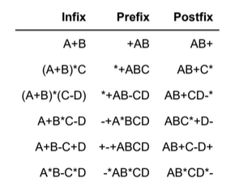

### Konversi Infix ke Postfix

Berikut algoritma untuk konversi ekspressi aritmatik infix ke postfix :

1. Buat struktur data stack untuk menampung operator
2. Baca ekspressi aritmatik dari kiri ke kanan tiap token :
- jika token yang dibaca adalah operand maka masukkan operand tersebut ke dalam output string
- jika token yang dibaca adalah kurung buka maka push kurung buka tersebut ke dalam stack
- jika token yang dibaca adalah kurang tutup maka pop stack semua token sampai ditemukan kurung buka jika token yang dibaca adalah operator maka :
- pop operator-operator yang memiliki precedence lebih tinggi atau sama dan masukkan operator tersebut ke dalam output string
- push token operator ke dalam stack
3. Jika masih terdapat operator pada stack, maka pop operator yang tersisa dan letakkan pada output string  
   Contoh konversi dari infix ke postfix dapat dilihat pada Gambar 5.

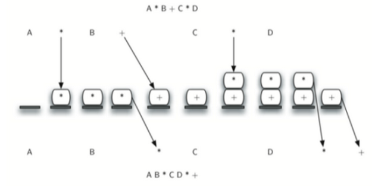

### Evaluasi Ekspressi Postfix

Seperti yang sudah dijelaskan sebelumnya, evaluasi untuk ekspressi aritmatika Postfix dilakukan setelah terdapat dua buah operand sebelum sebuah operator. Misalkan : 87+2*, yang berarti (8+7)*2=30, oleh karena itu berikut algoritma untuk mengevaluasi ekspressi aritmatika postfix :

1. baca string mulai dari kiri
2. Jika character yang dibaca adalah sebuah operand, maka push operand tersebut.
3. Jika character yang dibaca adalah sebuah operator, maka pop dua buah operand yang terdapat pada stack, operasikan dua buah operand tersebut dengan operator, dan push hasil operasinya
4. hasil akhir adalah angka terakhir yang terdapat di dalam stack

### Code

#### INFIX -> POSTFIX

```python
def prec(c):
    if c == '^':
        return 3
    elif c == '/' or c == '*':
        return 2
    elif c == '+' or c == '-':
        return 1
    else:
        return -1

def isRightAssociative(c):
    return c == '^'

def infixToPostfix(s):
    st = []
    res = []

    for c in s:
        # If operand, add to result
        if ('a' <= c <= 'z') or ('A' <= c <= 'Z') or ('0' <= c <= '9'):
            res.append(c)

        # If '(', push to stack
        elif c == '(':
            st.append('(')

        # If ')', pop until '('
        elif c == ')':
            while st and st[-1] != '(':
                res.append(st.pop())
            st.pop()

        # If operator
        else:
            while st and st[-1] != '(' and \
                (prec(st[-1]) > prec(c) or (prec(st[-1]) == prec(c) \
                                    and not isRightAssociative(c))):
                res.append(st.pop())
            st.append(c)

    # Pop remaining operators
    while st:
        res.append(st.pop())

    return ''.join(res)

if __name__ == '__main__':
    exp = "A+(B*C)"
    print(infixToPostfix(exp))
```

```
ABC*+
```

#### INFIX -> PREFIX

```python
# function to return precedence of operators
def precedence(c):
    if c == '^':
        return 3
    elif c in ('*', '/'):
        return 2
    elif c in ('+', '-'):
        return 1
    else:
        return -1

# function to check if operator is right-associative
def isRightAssociative(c):
    return c == '^'

# function to check if a character is an operator
def isOperator(c):
    return c in "+-*/^"

# function to convert infix expression to prefix
def infixToPrefix(s):
    st = []
    result = []

    # scan from right to left
    for c in reversed(s):
        if c.isalnum():
            result.append(c)
        elif c == ')':
            st.append(c)
        elif c == '(':
            while st and st[-1] != ')':
                result.append(st.pop())
            if st:
                st.pop()  # remove ')'
        elif isOperator(c):
            while (st and isOperator(st[-1]) and
                  (precedence(st[-1]) > precedence(c) or
                  (precedence(st[-1]) == precedence(c) and isRightAssociative(c)))):
                result.append(st.pop())
            st.append(c)

    # pop remaining operators
    while st:
        result.append(st.pop())

    # reverse at the end to get correct prefix
    return ''.join(reversed(result))

if __name__ == "__main__":
    s = input('Masukkan Infix = ')
    print(infixToPrefix(s))
```

```
+A/*BCD
```

#### PREFIX -> INFIX

```python
# Python Program to convert prefix to Infix
def prefixToInfix(prefix):
    stack = []

    # read prefix in reverse order
    i = len(prefix) - 1
    while i >= 0:
        if not isOperator(prefix[i]):

            # symbol is operand
            stack.append(prefix[i])
            i -= 1
        else:

            # symbol is operator
            str = "(" + stack.pop() + prefix[i] + stack.pop() + ")"
            stack.append(str)
            i -= 1

    return stack.pop()

def isOperator(c):
    if c == "*" or c == "+" or c == "-" or c == "/" or c == "^" or c == "(" or c == ")":
        return True
    else:
        return False

# Driver code
if __name__=="__main__":
    str = "/+78+32"
    print(prefixToInfix(str))
```

```
((7+8)/(3+2))
```